# Midterm Problem Set

Sokona Mangane

2023-03-16

# Problem 1

## Random()

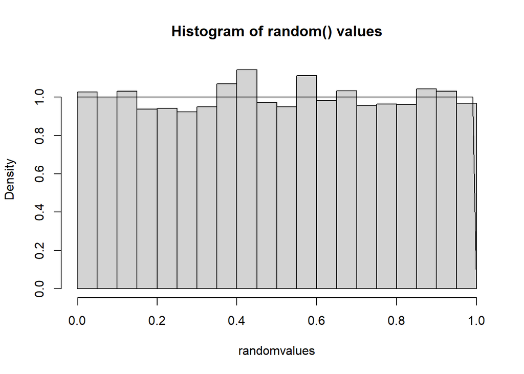

```r
randomvalues = scan("C:/Users/smangane/OneDrive - bates.edu/DCS307/Coding Files/.Rproj.user/MidtermPS/random.txt")
hist(randomvalues, freq = FALSE, main = "Histogram of random() values")
x <- seq(0,1, by = 0.0001)
curve(dunif(x), add = TRUE)
```

## Randint()

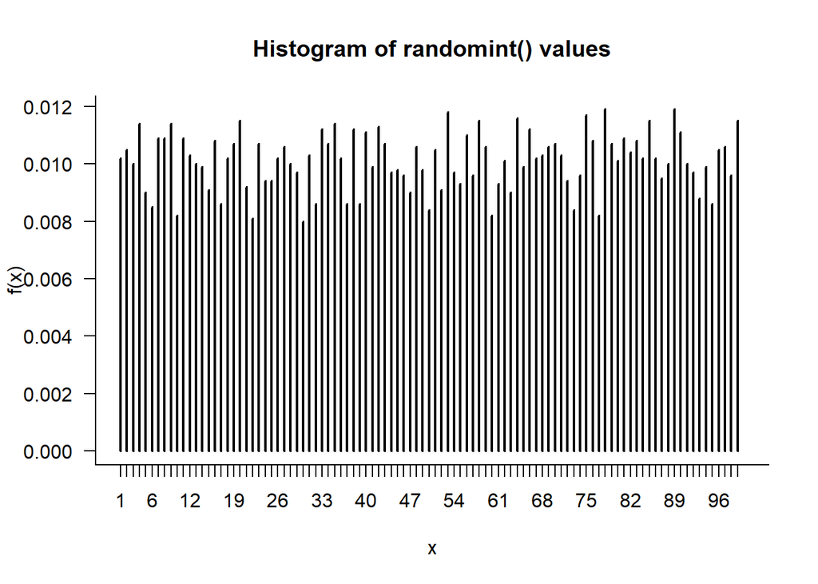

```r
randomintvalues = scan("C:/Users/smangane/OneDrive - bates.edu/DCS307/Coding Files/.Rproj.user/MidtermPS/randint.txt")

randomint_hist = table(randomintvalues) / length(randomintvalues)
plot(randomint_hist, xlim = c(1,100), type = "h", xlab = "x", ylab = "f(x)", bty = "l", las = 1)
points(1:99, dunif(1:99,100), pch = 40, col = "red")
title("Histogram of randomint() values")
```

## Uniform()

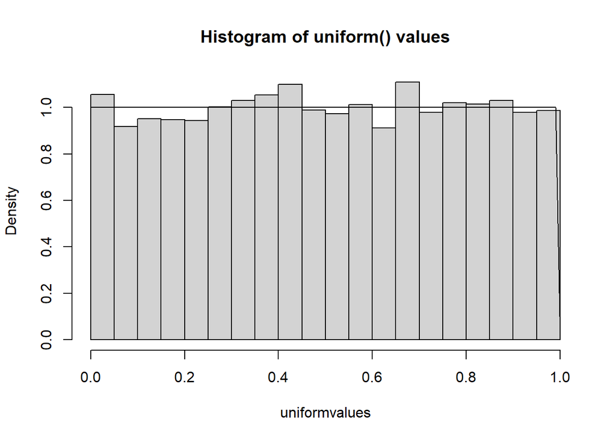

```r
uniformvalues = scan("C:/Users/smangane/OneDrive - bates.edu/DCS307/Coding Files/.Rproj.user/MidtermPS/uniform.txt")

hist(uniformvalues, freq = FALSE, main = "Histogram of uniform() values")
x <- seq(0,1, by = 0.0001)
curve(dunif(x), add = TRUE)
```

## Exponential()

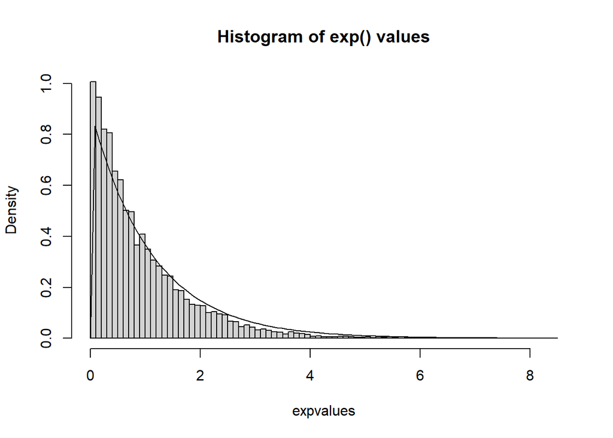

```r
expvalues = scan("C:/Users/smangane/OneDrive - bates.edu/DCS307/Coding Files/.Rproj.user/MidtermPS/exponential.txt")

hist(expvalues, freq = FALSE, main = "Histogram of exp() values", breaks = 100)
x <- seq(0,1, by = 0.0001)
curve(dexp(x, rate = 0.9), add = TRUE)
```

## Gamma()

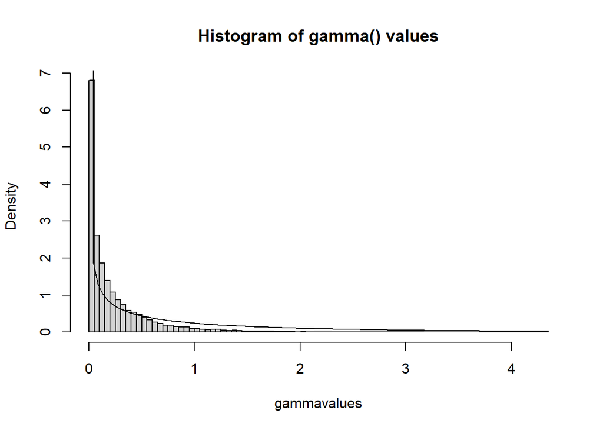

```r
gammavalues = scan("C:/Users/smangane/OneDrive - bates.edu/DCS307/Coding Files/.Rproj.user/MidtermPS/gamma.txt")


hist(gammavalues, freq = FALSE, main = "Histogram of gamma() values", breaks = 100)
x <- seq(0,4.35, by = 0.000435)
curve(dgamma(x, shape = 0.5, rate = 0.5), add = TRUE)
```

# Problem 2

If code below doesn’t work, see p2output file

## Part a

```python
import simulus
import random
from tabulate import tabulate
from RNG import RNG, Stream

class QueueStats: #writing a class
  time = []
  area_system = []
  area_queue = []
  num_in_system = 0
  num_in_queue = 0
  arrivals = 0
  departures = 0
  servertimes = []
  service_times = []
  total_time = 0
  serviceold = 0
  servicenew = 0
  nodecapacity = 0
  rejection = 0
  def show(self):
    print(f"For the service node capacity {self.nodecapacity}:")
    print(f"The number in the system @ the end: {self.num_in_system}")
    print(f"The total number of arrivals: {self.arrivals}")
    print(f"The total number of departures: {self.departures}")
    print(f"The average number in the system: {sum(self.area_system)/self.total_time}")
    print(f"The average queue in the system: {sum(self.area_queue)/self.total_time}")
    print(f"Utilization: {sum(self.servertimes)/self.total_time}")
    print(f"The average sojourn time: {sum(self.area_system)/self.arrivals}")
    print(f"The probability of rejection: {self.rejection/self.arrivals}")
    print("######")





def getInterarrival() -> float: #the arrival process
  return RNG.exponential(1/0.5, Stream.ARRIVAL)

def getService() -> float: #the service process
  #the number of service tasks equal to 1 + η, defined by rng.geometric
  totaltasks = RNG.geometric(0.1, Stream.COMPLETION) + 1
  totalservicetime = 0.0
  for t in range(totaltasks):
    #the time for each of the service tasks within a service process is,(independent of e.o.) is defined by rng.uniform
    totalservicetime += RNG.uniform(0.1, 0.2, Stream.SERVICE_TASK)
  return totalservicetime


#when someone completes a service
def completionOfService(queue_stats: QueueStats, show_output: bool = False) -> None: #is a departure equal to a complete?
  if show_output: print(f"Completion @ {sim.now}")

  #records current time (for step below)
  queue_stats.time.append(sim.now)

  #calculating the area of rectangles (integration) anytime there's a change (completion in this case) in the system
  #to calculate the average num and queue in system
  if len(queue_stats.time) > 1:
    change = (queue_stats.time[-1] - queue_stats.time[-2]) #difference
    queue_stats.area_system.append(change*queue_stats.num_in_system)
    queue_stats.area_queue.append(change*queue_stats.num_in_queue) #same calculation but for the queue

  #updating queue and max queue before we add the depature
  if queue_stats.num_in_system == 0:
    queue_stats.num_in_queue = 0
    #queue_stats.maxqueue = 0
  elif queue_stats.num_in_system == 1:
    #for utilization (if the server is BUSY), right before there's no one in the system,
    #servicenew = time when # in system goes from 1 to 0
    queue_stats.servicenew = sim.now
    #servertimes = area of rectangles for when the system is idle or busy
    queue_stats.servertimes.append(queue_stats.servicenew - queue_stats.serviceold)
    queue_stats.num_in_queue = queue_stats.num_in_system - 1
    #queue_stats.maxqueue = queue_stats.nodecapacity - 1
  else:
    queue_stats.num_in_queue = queue_stats.num_in_system - 1
    #queue_stats.maxqueue = queue_stats.nodecapacity - 1

  #now we actually remove someone from the system, and add them as a departure
  queue_stats.num_in_system -= 1
  queue_stats.departures += 1

  #if we've processed max. # of arrivals, record the total simulation time now
  if queue_stats.arrivals == maxArrivals:
    queue_stats.total_time = sim.now

  #if there's still more ppl in the system, schedule the next completion of service
  if queue_stats.num_in_system > 0:
    service_time = getService()
    queue_stats.service_times.append(service_time)
    sim.sched(completionOfService, queue_stats, until = sim.now + service_time) #schedules a time of complete at t + service_time
  else:
    pass


#when someone arrives
def arrival(queue_stats: QueueStats, show_output: bool = False) -> None: #show output is a boolean that automatically evaluates to true unless we specifiy otherwise
    if show_output: print(f"Arrival @ {sim.now}")

    #records current time (for step below)
    queue_stats.time.append(sim.now)

    #calculating the area of rectangles (integration) anytime there's a change (arrival in this case) in the system
    #to calculate the average num and queue in system
    if len(queue_stats.time) > 1:
      change = (queue_stats.time[-1] - queue_stats.time[-2])
      queue_stats.area_system.append(change*queue_stats.num_in_system)
      queue_stats.area_queue.append(change*queue_stats.num_in_queue)

    #updating queue and max queue before we add the arrival
    if queue_stats.num_in_system == 0:
      queue_stats.num_in_queue = 0
      #queue_stats.maxqueue = 0
      #for utilization, right before we add someone to system
      #servicold = when # in system goes from 0 to 1
      queue_stats.serviceold = sim.now
    else:
      queue_stats.num_in_queue = queue_stats.num_in_system - 1
      #queue_stats.maxqueue = queue_stats.nodecapacity - 1


    #now we actually add someone from the system
    queue_stats.num_in_system += 1

    #but if we're at capacity, then remove them from the system
    if queue_stats.num_in_system > queue_stats.nodecapacity:
      queue_stats.departures += 1
      queue_stats.rejection += 1
      queue_stats.num_in_system -= 1
    else: #if we're not, if there's someone in the system, schedule the next completion of service
      if queue_stats.num_in_system == 1:
        service_time = getService()
        queue_stats.service_times.append(service_time)
        sim.sched(completionOfService, queue_stats, until=sim.now + service_time)

    queue_stats.arrivals += 1

    #if we haven't reached max # of arrivals, schedule the next arrival
    if queue_stats.arrivals < maxArrivals:
      sim.sched(arrival, queue_stats, offset = getInterarrival()) #starts an arrival at the get interarrival time???

    if queue_stats.arrivals == maxArrivals:
      queue_stats.total_time = sim.now



#code to print table for (a) and (b)

results = []
Capacities = [1, 2, 3, 4, 5, 6]
for capacitiy in Capacities:
  sim = simulus.simulator()
  #making an object out of the class
  queue_stats = QueueStats()
  queue_stats.nodecapacity = capacitiy
  sim.sched(arrival, queue_stats, until = sim.now + getInterarrival())
  maxArrivals = 10000
  sim.run()
  #queue_stats.show()
  prob_rejection = queue_stats.rejection/queue_stats.arrivals
  avg_sojourn = (sum(queue_stats.area_system))/queue_stats.arrivals
  results.append([capacitiy, prob_rejection, avg_sojourn])
```

```
## <simulus.event._DirectEvent object at 0x0000024FB6473D00>
## <simulus.event._DirectEvent object at 0x0000024FB6473F70>
## <simulus.event._DirectEvent object at 0x0000024FB6473CD0>
## <simulus.event._DirectEvent object at 0x0000024FB6473FD0>
## <simulus.event._DirectEvent object at 0x0000024FB6473CD0>
## <simulus.event._DirectEvent object at 0x0000024FB6473CA0>
```

```python
head = ["Service Node Capacity [Uniform(0.1,0.2)]", "Est. Prob. of Rejection", "Est. Avg. Sojourn Time"]
print(tabulate(results, headers = head, tablefmt = 'fancy_grid'))
```

```
## ╒════════════════════════════════════════════╤═══════════════════════════╤══════════════════════════╕
## │   Service Node Capacity [Uniform(0.1,0.2)] │   Est. Prob. of Rejection │   Est. Avg. Sojourn Time │
## ╞════════════════════════════════════════════╪═══════════════════════════╪══════════════════════════╡
## │                                          1 │                    0.755  │                 0.375199 │
## ├────────────────────────────────────────────┼───────────────────────────┼──────────────────────────┤
## │                                          2 │                    0.6783 │                 1.16963  │
## ├────────────────────────────────────────────┼───────────────────────────┼──────────────────────────┤
## │                                          3 │                    0.6606 │                 2.45139  │
## ├────────────────────────────────────────────┼───────────────────────────┼──────────────────────────┤
## │                                          4 │                    0.6694 │                 4.20778  │
## ├────────────────────────────────────────────┼───────────────────────────┼──────────────────────────┤
## │                                          5 │                    0.6783 │                 6.47807  │
## ├────────────────────────────────────────────┼───────────────────────────┼──────────────────────────┤
## │                                          6 │                    0.6664 │                 9.22206  │
## ╘════════════════════════════════════════════╧═══════════════════════════╧══════════════════════════╛
```

## Part b

```python
import simulus
import random
from tabulate import tabulate
from RNG import RNG, Stream

class QueueStats: #writing a class
  time = []
  area_system = []
  area_queue = []
  num_in_system = 0
  num_in_queue = 0
  arrivals = 0
  departures = 0
  servertimes = []
  service_times = []
  total_time = 0
  serviceold = 0
  servicenew = 0
  nodecapacity = 0
  rejection = 0
  def show(self):
    print(f"For the service node capacity {self.nodecapacity}:")
    print(f"The number in the system @ the end: {self.num_in_system}")
    print(f"The total number of arrivals: {self.arrivals}")
    print(f"The total number of departures: {self.departures}")
    print(f"The average number in the system: {sum(self.area_system)/self.total_time}")
    print(f"The average queue in the system: {sum(self.area_queue)/self.total_time}")
    print(f"Utilization: {sum(self.servertimes)/self.total_time}")
    print(f"The average sojourn time: {sum(self.area_system)/self.arrivals}")
    print(f"The probability of rejection: {self.rejection/self.arrivals}")
    print("######")





def getInterarrival() -> float: #the arrival process
  return RNG.exponential(1/0.5, Stream.ARRIVAL)

def getService() -> float: #the service process
  #the number of service tasks equal to 1 + η, defined by rng.geometric
  totaltasks = RNG.geometric(0.1, Stream.COMPLETION) + 1
  totalservicetime = 0.0
  for t in range(totaltasks):
    #the time for each of the service tasks within a service process is,(independent of e.o.) is defined by rng.uniform
    totalservicetime += RNG.uniform(0.1, 0.3, Stream.SERVICE_TASK)
  return totalservicetime


#when someone completes a service
def completionOfService(queue_stats: QueueStats, show_output: bool = False) -> None: #is a departure equal to a complete?
  if show_output: print(f"Completion @ {sim.now}")

  #records current time (for step below)
  queue_stats.time.append(sim.now)

  #calculating the area of rectangles (integration) anytime there's a change (completion in this case) in the system
  #to calculate the average num and queue in system
  if len(queue_stats.time) > 1:
    change = (queue_stats.time[-1] - queue_stats.time[-2]) #difference
    queue_stats.area_system.append(change*queue_stats.num_in_system)
    queue_stats.area_queue.append(change*queue_stats.num_in_queue) #same calculation but for the queue

  #updating queue and max queue before we add the depature
  if queue_stats.num_in_system == 0:
    queue_stats.num_in_queue = 0
    #queue_stats.maxqueue = 0
  elif queue_stats.num_in_system == 1:
    #for utilization (if the server is BUSY), right before there's no one in the system,
    #servicenew = time when # in system goes from 1 to 0
    queue_stats.servicenew = sim.now
    #servertimes = area of rectangles for when the system is idle or busy
    queue_stats.servertimes.append(queue_stats.servicenew - queue_stats.serviceold)
    queue_stats.num_in_queue = queue_stats.num_in_system - 1
    #queue_stats.maxqueue = queue_stats.nodecapacity - 1
  else:
    queue_stats.num_in_queue = queue_stats.num_in_system - 1
    #queue_stats.maxqueue = queue_stats.nodecapacity - 1

  #now we actually remove someone from the system, and add them as a departure
  queue_stats.num_in_system -= 1
  queue_stats.departures += 1

  #if we've processed max. # of arrivals, record the total simulation time now
  if queue_stats.arrivals == maxArrivals:
    queue_stats.total_time = sim.now

  #if there's still more ppl in the system, schedule the next completion of service
  if queue_stats.num_in_system > 0:
    service_time = getService()
    queue_stats.service_times.append(service_time)
    sim.sched(completionOfService, queue_stats, until = sim.now + service_time) #schedules a time of complete at t + service_time
  else:
    pass


#when someone arrives
def arrival(queue_stats: QueueStats, show_output: bool = False) -> None: #show output is a boolean that automatically evaluates to true unless we specifiy otherwise
    if show_output: print(f"Arrival @ {sim.now}")

    #records current time (for step below)
    queue_stats.time.append(sim.now)

    #calculating the area of rectangles (integration) anytime there's a change (arrival in this case) in the system
    #to calculate the average num and queue in system
    if len(queue_stats.time) > 1:
      change = (queue_stats.time[-1] - queue_stats.time[-2])
      queue_stats.area_system.append(change*queue_stats.num_in_system)
      queue_stats.area_queue.append(change*queue_stats.num_in_queue)

    #updating queue and max queue before we add the arrival
    if queue_stats.num_in_system == 0:
      queue_stats.num_in_queue = 0
      #queue_stats.maxqueue = 0
      #for utilization, right before we add someone to system
      #servicold = when # in system goes from 0 to 1
      queue_stats.serviceold = sim.now
    else:
      queue_stats.num_in_queue = queue_stats.num_in_system - 1
      #queue_stats.maxqueue = queue_stats.nodecapacity - 1


    #now we actually add someone from the system
    queue_stats.num_in_system += 1

    #but if we're at capacity, then remove them from the system
    if queue_stats.num_in_system > queue_stats.nodecapacity:
      queue_stats.departures += 1
      queue_stats.rejection += 1
      queue_stats.num_in_system -= 1
    else: #if we're not, if there's someone in the system, schedule the next completion of service
      if queue_stats.num_in_system == 1:
        service_time = getService()
        queue_stats.service_times.append(service_time)
        sim.sched(completionOfService, queue_stats, until=sim.now + service_time)

    queue_stats.arrivals += 1

    #if we haven't reached max # of arrivals, schedule the next arrival
    if queue_stats.arrivals < maxArrivals:
      sim.sched(arrival, queue_stats, offset = getInterarrival()) #starts an arrival at the get interarrival time???

    if queue_stats.arrivals == maxArrivals:
      queue_stats.total_time = sim.now



#code to print table for (a) and (b)

results = []
Capacities = [1, 2, 3, 4, 5, 6]
for capacitiy in Capacities:
  sim = simulus.simulator()
  #making an object out of the class
  queue_stats = QueueStats()
  queue_stats.nodecapacity = capacitiy
  sim.sched(arrival, queue_stats, until = sim.now + getInterarrival())
  maxArrivals = 10000
  sim.run()
  #queue_stats.show()
  prob_rejection = queue_stats.rejection/queue_stats.arrivals
  avg_sojourn = (sum(queue_stats.area_system))/queue_stats.arrivals
  results.append([capacitiy, prob_rejection, avg_sojourn])
```

```
## <simulus.event._DirectEvent object at 0x0000024FB6473FA0>
## <simulus.event._DirectEvent object at 0x0000024FB6C96880>
## <simulus.event._DirectEvent object at 0x0000024FB6473A00>
## <simulus.event._DirectEvent object at 0x0000024FB6C96070>
## <simulus.event._DirectEvent object at 0x0000024FB6473D30>
## <simulus.event._DirectEvent object at 0x0000024FB6C960D0>
```

```python
head = ["Service Node Capacity [Uniform(0.1,0.3)]", "Est. Prob. of Rejection", "Est. Avg. Sojourn Time"]
print(tabulate(results, headers = head, tablefmt = 'fancy_grid'))
```

```
## ╒════════════════════════════════════════════╤═══════════════════════════╤══════════════════════════╕
## │   Service Node Capacity [Uniform(0.1,0.3)] │   Est. Prob. of Rejection │   Est. Avg. Sojourn Time │
## ╞════════════════════════════════════════════╪═══════════════════════════╪══════════════════════════╡
## │                                          1 │                    0.7924 │                 0.405369 │
## ├────────────────────────────────────────────┼───────────────────────────┼──────────────────────────┤
## │                                          2 │                    0.7683 │                 1.2636   │
## ├────────────────────────────────────────────┼───────────────────────────┼──────────────────────────┤
## │                                          3 │                    0.7527 │                 2.59525  │
## ├────────────────────────────────────────────┼───────────────────────────┼──────────────────────────┤
## │                                          4 │                    0.7554 │                 4.42442  │
## ├────────────────────────────────────────────┼───────────────────────────┼──────────────────────────┤
## │                                          5 │                    0.7634 │                 6.80917  │
## ├────────────────────────────────────────────┼───────────────────────────┼──────────────────────────┤
## │                                          6 │                    0.7471 │                 9.65759  │
## ╘════════════════════════════════════════════╧═══════════════════════════╧══════════════════════════╛
```

## Part c

If we compare the histograms, looking at the quantiles and means for both service models, the service model where the time for each of the service tasks within a service process is a *uniform*(0.1, 0.2) random variate, is a little faster since it’s service times are lower.

### *Uniform*(0.1,0.2)

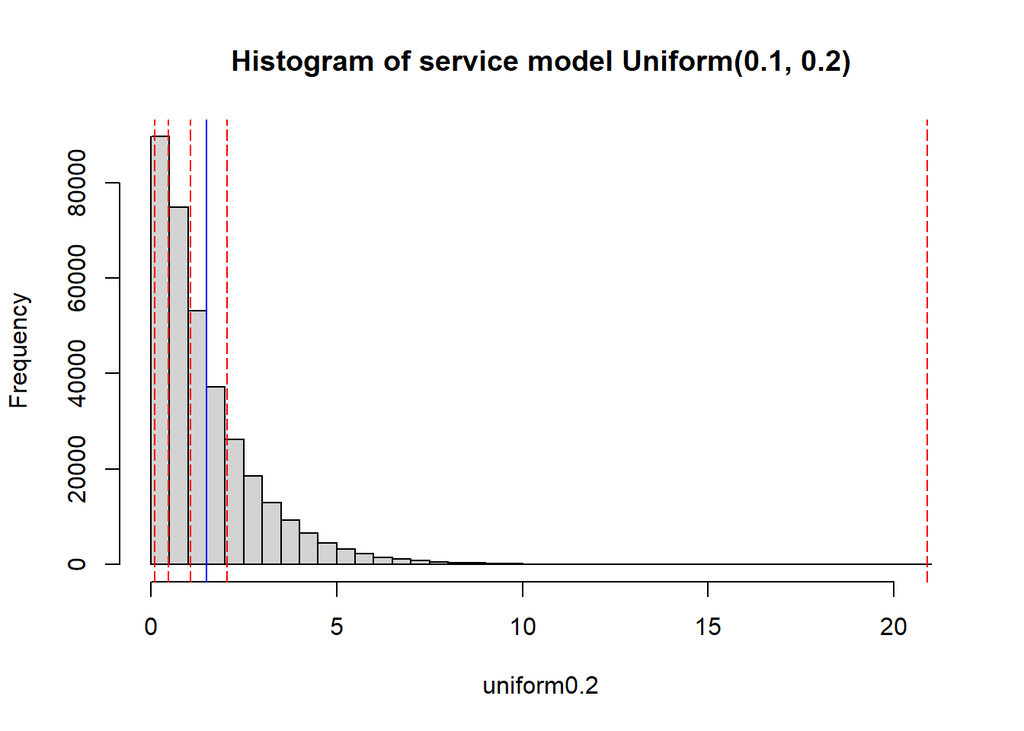

```r
uniform0.2 = scan("C:/Users/smangane/OneDrive - bates.edu/DCS307/Coding Files/.Rproj.user/uniform0.2st.txt")
hist(uniform0.2, breaks = 50, main = "Histogram of service model Uniform(0.1, 0.2)")
m.2 <- mean(uniform0.2)
abline(v = m.2, col = "blue")
c.2 <- quantile(uniform0.2)
abline(v = c.2, col = "red", lty = 5)
```

Mean: 1.4985087 Quantiles: 0.1000039, 0.4809897, 1.0603742, 2.0476677, 20.8987845

### *Uniform*(0.1,0.3)

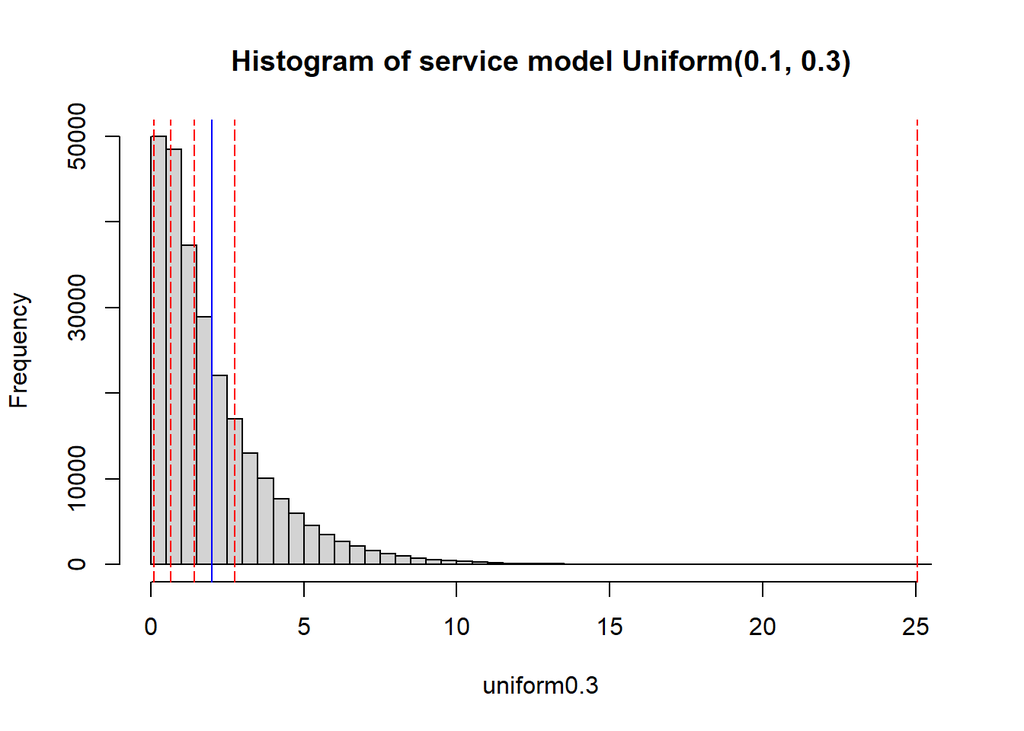

```r
uniform0.3 = scan("C:/Users/smangane/OneDrive - bates.edu/DCS307/Coding Files/.Rproj.user/uniform0.3st.txt")
hist(uniform0.3, breaks = 50, main = "Histogram of service model Uniform(0.1, 0.3)")
m.3 <- mean(uniform0.3)
abline(v = m.3, col = "blue")
c.3 <- quantile(uniform0.3)
abline(v = c.3, col = "red", lty = 5)
```

Mean: 1.9968027 Quantiles: 0.1000024, 0.6425413, 1.414909, 2.7329409, 25.0589288